# 1. Giới thiệu và cài đặt Anaconda

# 2. Cú pháp chính trong lập trình với Python

### Phép gán

Cú pháp : tendoituong = bieuthuc

```python
x=2
y=4
x+y
```

```
6
```

```python
x=[1,4,6,7,9,8]
x
```

```
[1, 4, 6, 7, 9, 8]
```

```python
x[0]
```

```
1
```

```python
x[3]
```

```
7
```

```python
x[1:4]
```

[output not shown]

### Toán tử cơ bản trong python

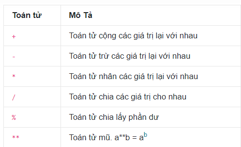

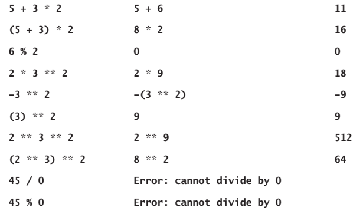

### Toán tử quan hệ trong Python

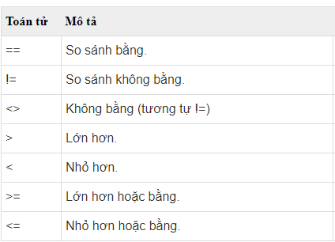

### Mệnh đề lựa chọn if

Trong Python, khối lệnh của if bắt đầu với một khoảng thụt lề và dòng không thụt lề đầu tiên sẽ được hiểu là kết thúc lệnh if.

**Cú pháp** :

if *điều kiện*:

*khối lệnh*

```python
num = 3
if num > 0:
   print(num, "là số dương.")

print("Thông điệp này luôn được in.")

num = -1
if num > 0:
   print(num, "là số dương.")
print("Thông điệp này luôn luôn được in")
```

```
3 là số dương.
Thông điệp này luôn được in.
Thông điệp này luôn luôn được in
```

Trong ví dụ trên, num > 0 là điều kiện, khối lệnh của if được thực thi khi thỏa mãn điều kiện. Khi num bằng 3, kiểm tra điều kiện, thấy đúng, khối lệnh của if được thực thi. Khi num bằng -1, không khỏa mãn điều kiện, khối lệnh của if bị bỏ qua và thực hiện lệnh print() cuối cùng.

### Mệnh đề lựa chọn if ... else

Trong Python, thụt đầu dòng được sử dụng để tách các khối lệnh.

**Cú pháp** :

if *điều kiện*:

return *khối lệnh 1*.

else:

return *khối lệnh 2*.

```python
# Kiem tra xem so am hay duong
# Va hien thi thong bao phu hop

num = 3

if num >= 0:
   print("So duong hoac bang 0")
else:
   print("So am")

num1=-1

if num1 >= 0:
   print("So duong hoac bang 0")
else:
   print("So am")
```

```
So duong hoac bang 0
So am
```

```python
first = int(input("Enter the first number: "))
second = int(input("Enter the second number: "))
if first > second:
    maximum = first
    minimum = second
else:
    maximum = second
    minimum = first
print("Maximum:", maximum)
print("Minimum:", minimum)
```

```
Enter the first number: 35
Enter the second number: 98
Maximum: 98
Minimum: 35
```

```python
number = int(input("Enter the numeric grade: "))
if number > 89:
    letter = 'A'
elif number > 79:
    letter = 'B'
elif number > 69:
    letter = 'C'
else:
    letter = 'F'
print("The letter grade is", letter)
```

### Mệnh đề lặp của for

for *i* in *chuoi_lap*:

```
Khối lệnh của for
```

Trong cú pháp trên, chuoi_lap là chuỗi cần lặp, *i* là biến nhận giá trị của từng mục bên trong chuoi_lap trên mỗi lần lặp.

Khối lệnh của for được thụt lề để phân biệt với phần còn lại của code.

```python
#Lặp chữ cái trong quantrimang
for i in 'Hello':
    print('Chữ cái hiện tại:', i)
```

```
Chữ cái hiện tại: H
Chữ cái hiện tại: e
Chữ cái hiện tại: l
Chữ cái hiện tại: l
Chữ cái hiện tại: o
```

```python
# Tính tổng tất cả các số trong danh sách A
# Danh sách A
A = (1, 3, 5, 9, 11, 2, 6, 8, 10)
# Biến để lưu trữ tổng các số là tong, gán giá trị ban đầu bằng 0
tong = 0
# Vòng lặp for, a là biến lặp
for i in A:
     tong = tong+i
# Đầu ra: Tổng các số là 55
print("Tổng các số là", tong)
```

```
Tổng các số là 55
```

### Mệnh đề while

while *điều_kiện_kiểm_tra*:

```
  Khối lệnh của while
```

```python
count = 0
n = 0
while (count < 8):
      print ('Số thứ', n,' là:', count)
      n = n + 1
      count = count + 1
print ("Đã hết vòng lặp white!")
```

```
Số thứ 0  là: 0
Số thứ 1  là: 1
Số thứ 2  là: 2
Số thứ 3  là: 3
Số thứ 4  là: 4
Số thứ 5  là: 5
Số thứ 6  là: 6
Số thứ 7  là: 7
Đã hết vòng lặp white!
```

Trong ví dụ trên, khi *count* thỏa điều kiện lặp, khối lệnh của *while* sẽ được thực thi. Khi *count* không thỏa điều kiện, khối lệnh của *white* sẽ không thực hiện và in ra dòng lệnh kế tiếp bên ngoài vòng *white*.

### Cú pháp của hàm trong Python

**def** *ten_ham*(*các tham số*):

*Các câu lệnh thực thi của hàm*

1. def: Đánh dấu sự bắt đầu của tiêu đề hàm.
2. ten_ham: Là định danh duy nhất dành cho hàm.
3. *Các tham số*: Các tham số sẽ truyền vào hàm này.
4. Dấu hai chấm (:): Đánh dấu sự kết thúc của tiêu đề hàm.
5. *Các câu lệnh*: Một hoặc nhiều lệnh tạo thành khối lệnh, các lệnh này phải có cùng một mức thụt đầu dòng (thường là 4 khoảng trắng).
6. Lệnh *return*: Lệnh này là tùy chọn, dùng khi cần trả về giá trị từ hàm.

```python
def phepnhan(n):

    return n*10

phepnhan(5)
```

```
50
```

```python
def hello():
    print("HELLO")

hello()
hello()
```

```
HELLO
HELLO
```

### Hàm range() trả về một danh sách các số

**Cú pháp 1**

*range(stop)*

**Cú pháp 2**

*range(start, stop,step)*

Hàm range() có 3 tham số:

- start: số nguyên bắt đầu, chuỗi sẽ bắt đầu với tham số này. Giá trị mặc định là 0.
- stop: số nguyên kết thúc, chuỗi sẽ kết thúc với tham số này.
- step: số nguyên xác định khoảng cách giữa các số bên trong chuỗi. Giá trị mặc định là 1.

```python
start = 2
stop = 14
step = 2
print(list(range(0)))

# sử dụng range(stop)
print(list(range(stop)))

# sử dụng range(start, stop)
print(list(range(start, stop)))

# sử dụng range(start, stop,step)
print(list(range(start, stop, step)))
```

```
[]
[0, 1, 2, 3, 4, 5, 6, 7, 8, 9, 10, 11, 12, 13]
[2, 3, 4, 5, 6, 7, 8, 9, 10, 11, 12, 13]
[2, 4, 6, 8, 10, 12]
```

# 3. Python và các thư viện tính toán khoa học

[Python](https://www.python.org/) là ngôn ngữ lập trình được dùng phổ biến cho tính toán khoa học (và nhiều mục đích khác). Tài liệu tra cứu chính thống của Python được để ở [Python documentation](https://docs.python.org/3/index.html). Có thể dùng hướng dẫn từ các tài liệu tham khảo

[The Python Tutorial](https://docs.python.org/3/tutorial/)

[Python3 Tutorial](https://www.python-course.eu/python3_course.php)

[Numerical Programming with Python](https://www.python-course.eu/numerical_programming_with_python.php)

[GeeksforGeeks](https://www.geeksforgeeks.org/python-programming-language/), ...

Các thư viện Python phổ biến dùng trong tính toán khoa học là: [NumPy](https://numpy.org/), [SciPy](https://www.scipy.org/), [SymPy](https://www.sympy.org/en/index.html), [pandas](https://pandas.pydata.org/), [scikit-learn](https://scikit-learn.org/stable/), [Matplotlib](https://matplotlib.org/), ....

Tra cứu các hỗ trợ cho **đại số tuyến tính** (linear algebra) tại:

- [Linear algebra (numpy.linalg)](https://numpy.org/doc/stable/reference/routines.linalg.html#)
- [Linear algebra (scipy.linalg)](https://docs.scipy.org/doc/scipy/reference/linalg.html#module-scipy.linalg)
- [SymPy Matrices (linear algebra)](https://docs.sympy.org/latest/modules/matrices/matrices.html)

Để cài đặt 1 thư viện (package) mới trong Python, sử dụng lệnh **import**. Ví dụ ta muốn cài đặt gói thư viện *numpy*

```python
import numpy
```

Lệnh trên được áp dụng và các hàm có trong thư viện *numpy* sẽ được áp dụng. Khi muốn gọi thư viện *numpy* ta sẽ nhập *numpy*.

Đơn giản hơn, ta có thể thực hiện cài đặt thư viện *numpy* như sau.

```python
import numpy as np
```

Với cách gán như trên, khi cần gọi thư viện *numpy* ta chỉ cần gõ *np* thay vì *numpy*.

Đối với mọi Jupyter Notebook, ta chỉ cần chạy câu lệnh nhập thư viện một lần và có thể sử dụng gói đã nhập cho phần còn lại của cùng một notebook.

# 4. Cú pháp một số hàm được sử dụng trong phần thực hành

```python
import numpy as np
```

## 4.1. Vector

Một bộ gồm $n$ số thực (n-tuple) $\boldsymbol{v} = (v_1, v_2, ..., v_n) \in \mathbb{R}^n$ được gọi là một **vector** kích thước $n$. Các số $v_1, v_2, ..., v_n \in \mathbb{R}$ được gọi là các **phần tử** (element, entry) của vector. Để phân biệt với vector, các số thực còn được gọi là **vô hướng** (scalar).

- Để tạo vector, ta có thể dùng kiểu *list* đã có sẵn trên Python bằng cú pháp [$v_1$,$v_2$,$\dots$,$v_n$] với $v_1$,$v_2$,$\dots$,$v_n$ là các phần tử của vector.
- Hoặc có thể sử dụng hàm `np.array[]` của thư viện `numpy` bằng cú pháp [$v_1$,$v_2$,$\dots$,$v_n$].
- Hoặc có thể sử dụng hàm `Matrix([])` của thư viện `sympy`, với vector sẽ được biểu diễn dưới dạng cột.

Khi muốn truy cập một phần tử bất kỳ trong vector, ta gọi tên của vector đã đặt và kèm theo chỉ số thứ tự của phần tử cần xuất. Với lưu ý trong python, số thứ tự của phần tử trong vector được đánh dấu từ **0** đến **n-1** hoặc từ **-n** đến **-1**.

```python
v = [12,23,25,34,50,49,27]; ## cách 1 để nhập vector
w = np.array([12,23,25,34,50,49,27]) ## dùng hàm array trong thư viện numpy
print("Kích thước của vector w là :",len(w))
print(v)
print(w)
## Truy cập entry, subsector theo thứ tự của mảng được đánh số từ 0 đến n-1 hoặc từ -n đến -1
print(w[0]) # in ra phần tử thứ 0 của mảng
print(w[-1]) # in ra phần tử cuối cùng của mảng
print(w[-5]) # in ra phần tử thứ 5 tính từ bên phải sang
print(w[:2]) # in ra phần tử đầu tiên đến phần tử thứ 1
print(w[3:]) # in ra phần tử thứ 4 đến hết
print(v[1:4]) # in ra phần tử từ thứ 1 đến thứ 3
```

```
Kích thước của vector w là : 7
[12, 23, 25, 34, 50, 49, 27]
[12 23 25 34 50 49 27]
12
27
25
[12 23]
[34 50 49 27]
[23, 25, 34]
```

```python
w = np.array([12,23,25,34,50,49,27])
w[5] = 1234 ## gán phần tử thứ 5 của mảng bằng 1234
w ## in ra mảng w và phần tử thứ 5 đã được thay đổi
```

```
array([  12,   23,   25,   34,   50, 1234,   27])
```

```python
v = np.array([1, 2, 3]); w = np.array([4, 5, 6])
print(v * w, v / w, v ** w)
print(v + 3, w * 3, -v)
```

```
[ 4 10 18] [0.25 0.4  0.5 ] [  1  32 729]
[4 5 6] [12 15 18] [-1 -2 -3]
```

### Tích vô hướng giữa 2 vector

Để tìm tích vô hướng giữa 2 vector trong thư viện `Numpy` ta dùng các hàm `np.inner(u,v)` hoặc phép tính `u@v`.

### Input

- *u,v*: 2 vector cần tìm tích vô hướng.

### Ouput

- Tích vô hướng giữa *u,v*.

```python
u = [1, 3, -2, 7]; v = [0, 7, 2, 2]
np.inner(u,v)
```

```
31
```

```python
u1=np.array(u)
v1=np.array(v)
u1@v1
```

```
31
```

Trong thư viện `Numpy` để tìm chuẩn của vector *u*, ta dùng lệnh `np.linalg.norm(u)`.

### Input

- *u* vector cần tìm chuẩn

### Output

- Chuẩn của vector *u*.

## 4.2. Giới thiệu ma trận

## Nhập ma trận

- Để nhập ma trận, ta có thể dùng **danh sách lồng** (nested list) các số `[[dòng 1],[dòng 2],...,[dòng m]]`.
- Hoăc có thể sử dụng mảng 2 chiều trong thư viện `numpy`, `np.array([[dòng 1],[dòng 2],...,[dòng m]]) Cách đơn giản nhất để biểu diễn ma trận là dùng **danh sách lồng** (nested list) các số. Cách hiệu quả và tiện lợi hơn là dùng **NumPy 2D array**.

```python
A = [[0,2,1],
              [1,4,6]]
## Với ví dụ trên ma trận A có kích thước 2 dòng, 3 cột với dòng 1 là các phần tử 0,2,1 dòng 2 là 1,4,6
A
```

```
[[0, 2, 1], [1, 4, 6]]
```

```python
A = np.array([[0,2,1],
              [1,4,6]])
## Với ví dụ trên ma trận A có kích thước 2 dòng, 3 cột với dòng 1 là các phần tử 0,2,1 dòng 2 là 1,4,6

print(A, A.shape)
```

```
[[0 2 1]
 [1 4 6]] (2, 3)
```

```python
import sympy
from sympy import Matrix
```

```python
A = Matrix([[sympy.symbols(f"a_{i}{j}") for j in range(1, 4)] for i in range(1, 3)])
A.T
```

$\displaystyle \left[\begin{matrix}a_{11} & a_{21}\\a_{12} & a_{22}\\a_{13} & a_{23}\end{matrix}\right]$

### Đồ án

1) Sinh viên viết hàm `Gauss_elimination(A)`, trong đó

- Input: A ma trận mở rộng của hệ phương trình.
- Output: ma trận có dạng bậc thang có được từ ma trận A.

Sinh viên không được dùng các hàm có sẵn của các thư viện để tìm ma trận bậc thang.

2) Sinh viên viết hàm `back_substitution(A)`, trong đó

- Input: A ma trận có dạng bậc thang từ từ ma trận mở rộng của hệ phương trình Ax=b.
- Output: nghiệm của hệ phương trình ( trường hợp nghiệm duy nhất/ vô số nghiệm ) hoặc thông báo hệ phương trình vô nghiệm.

Sinh viên không được dùng các hàm có sẵn của các thư viện để tìm ma trận bậc thang.

### Quy định bài nộp

- Thực hiện toàn bộ bài làm trên 1 tập tin Jupyter Notebook (.ipynb) hoặc Python (.py)
- Bạn nộp tập tin `MSSV.zip` được nén từ thư mục MSSV chứa các tập tin sau:
  1. Báo cáo toàn bộ bài làm: `MSSV.pdf`
  2. Mã nguồn: `MSSV.ipynb` hoặc `MSSV.py`
- Trong đó, nội dung tập tin báo cáo gồm có:
  - Thông tin cá nhân: họ và tên, MSSV
  - Ý tưởng thực hiện, mô tả các hàm
- Ví dụ minh họa cây thư mục bài nộp sau khi giải nén tập tin `MSSV.zip` như sau:

  ```
  MSSV
  ├── MSSV.pdf
  └── MSSV.ipynb
  ```

### Quy định chấm bài

Những trường hợp sau đây sẽ bị 0 điểm toàn bộ đồ án:

- Nộp sai quy định
- Không có báo cáo
- Thực thi mã nguồn báo lỗi

**LƯU Ý: SAO CHÉP BÀI LÀM CỦA NHAU SẼ BỊ 0 ĐIỂM TOÀN BỘ PHẦN THỰC HÀNH**

Hệ PTTT $A\boldsymbol{x} = \boldsymbol{b}$ thường được giải bằng các bước:

> **Bước 1.** Lập **ma trận bổ sung** (augmented matrix) bằng cách ghép cột $\boldsymbol{b}$ sau ma trận $A$: $\bar{A} = \left[ A | \boldsymbol{b} \right]$.

> **Bước 2.** Dùng các phép biến đổi sơ cấp trên dòng để biến đổi $\bar{A}$ thành ma trận tương đương dòng có dạng bậc thang $R$.

> **Bước 3.** Giải $R$ bằng **phép thế ngược** (back-substitution) để có nghiệm.

## Phép khử Gauss

**Khử Gauss** (Gaussian elimination) là một cách biến đổi tương đương dòng đưa ma trận về dạng bậc thang. Thuật giải gồm các bước:

> **Bước 1.** Xác định cột trái nhất không chứa toàn số 0.

> **Bước 2.** Đổi chỗ hai dòng, nếu cần thiết, để đưa số hạng khác 0 nào đó ở dưới về đầu cột nhận được ở Bước 1.  
> (*Đơn giản nhất, có thể chọn dòng đầu tiên có số hạng khác 0. Phức tạp hơn, chiến lược "partial pivoting" chọn dòng có số hạng có trị tuyệt đối lớn nhất.*)

> **Bước 3.** Với số hạng đầu cột nhận được từ Bước 2 là $a \neq 0$, nhân dòng chứa nó với $\frac{1}{a}$ để có **số dẫn đầu** 1 (leading 1).  
> (*Bước này tùy chọn*.)

> **Bước 4.** Cộng một bội số thích hợp của dòng đầu cho từng dòng dưới để biến các số hạng bên dưới số dẫn đầu thành 0.

> **Bước 5.** Che dòng đầu đã làm xong. Lặp lại các bước cho đến khi được ma trận bậc thang.

```python
import math
def is_zero(x):
    "kiểm tra số thực x có là số thực 0 (rất gần 0)"
    return math.isclose(x, 0, abs_tol=1e-09)

def mul_scalar_vector(alpha, v):
    return [alpha*vi for vi in v]

def add_vector(v, w):
    return [vi + wi for vi, wi in zip(v, w)]

def row_switch(A, i, k):
    "di <-> dk"
    A[i], A[k] = A[k], A[i]

def row_mul(A, i, alpha):
    "di = anpha*di"
    A[i] = mul_scalar_vector(alpha, A[i])

def row_add(A, i, k, alpha):
    "di = di + anpha*dk"
    A[i] = add_vector(A[i], mul_scalar_vector(alpha, A[k]))
```

```python
def Gauss_elimination(A):
    R = A.copy()
    n_row, n_col = len(R), len(R[0]) # kích thước ma trận
    row = col = 0
    while row < n_row:
        # Bước 1
        while col < n_col and all(is_zero(R[i][col]) for i in range(row, n_row)):
            col += 1
        if col == n_col: # đã có dạng bậc thang
            break

        # Bước 2 (chọn dòng đầu tiên có số hạng khác 0)
        pivot_row = row + [not is_zero(R[i][col]) for i in range(row, n_row)].index(True)
        row_switch(R, row, pivot_row)

        # Bước 3
        row_mul(R, row, 1/R[row][col])

        # Bước 4
        for i in range(row + 1, n_row):
            row_add(R, i, row, -R[i][col])

        # Bước 5
        row += 1
    return R
```

```python
A=[[1,2,-1,-1],[2,2,1,1],[3,5,-2,-1]]
R1=Gauss_elimination(A)
print(R1)
```

```
[[1.0, 2.0, -1.0, -1.0], [-0.0, 1.0, -1.5, -1.5], [-0.0, -0.0, 1.0, -1.0]]
```

```python
B=[[1,-2,-1,1],[2,-3,1,6],[3,-5,0,7],[1,0,5,9]]
R2=Gauss_elimination(B)
print(R2)
```

```
[[1.0, -2.0, -1.0, 1.0], [0.0, 1.0, 3.0, 4.0], [0.0, 0.0, 0.0, 0.0], [0.0, 0.0, 0.0, 0.0]]
```

```python
C=[[1,2,0,2,6],[3,5,-1,6,17],[2,4,1,2,12],[2,0,-7,11,7]]
R3=Gauss_elimination(C)
print(R3)
```

```
[[1.0, 2.0, 0.0, 2.0, 6.0], [-0.0, 1.0, 1.0, -0.0, 1.0], [0.0, 0.0, 1.0, -2.0, 0.0], [0.0, 0.0, 0.0, 1.0, -1.0]]
```

```python
D=[[2,-4,-1,1],[1,-3,1,1],[3,-5,-3,2]]
R4=Gauss_elimination(D)
print(R4)
```

```
[[1.0, -2.0, -0.5, 0.5], [-0.0, 1.0, -1.5, -0.5], [0.0, 0.0, 0.0, 1.0]]
```

```python
import sympy
def back_substitution(R):
    "R là ma trận bậc thang của ma trận bổ sung của hệ phương trình Ax = b"
    n_row, n_col = len(R), len(R[0]) # kích thước ma trận R

    # vector nghiệm (danh sách theo thứ tự ẩn)
    sol = [None for _ in range(n_col - 1)]

    # Tìm dòng dưới cùng khác không
    row = n_row - 1
    while row >= 0 and all(is_zero(R[row][j]) for j in range(n_col)):
        row -= 1

    if row >= 0 and [not is_zero(R[row][j]) for j in range(n_col)].index(True) == n_col - 1:
        print("Hệ phương trình tuyến tính vô nghiệm") # vô nghiệm
        return None

    last_pcol = n_col - 1
    while row >= 0:
        pcol = [not is_zero(R[row][j]) for j in range(n_col)].index(True)
        for i in range(pcol, last_pcol): # các ẩn tự do
            sol[i] = sympy.symbols(f"x{i + 1}")
        sol[pcol] = R[row][n_col - 1] - sum(R[row][j]*sol[j] for j in range(pcol + 1, n_col - 1))
        last_pcol = pcol
        row -= 1

    # Bổ sung các ẩn tự do từ 0 đến last_pcol - 1
    for i in range(0, last_pcol):
        sol[i] = sympy.symbols(f"x{i + 1}")
    return sol
```

```python
back_substitution(R1)
```

```
[4.0, -3.0, -1.0]
```

```python
back_substitution(R2)
```

```
[9.0 - 5.0*x3, 4.0 - 3.0*x3, x3]
```

```python
back_substitution(R3)
```

```
[2.0, 3.0, -2.0, -1.0]
```

```python
back_substitution(R4)
```

```
Hệ phương trình tuyến tính vô nghiệm
```